# CAD1 Analysis

Scott Bannister

2024-10-10

# **Descriptives**

Generate basic histogram for Basic Audio Quality (BAQ) distribution; note the zero inflation:

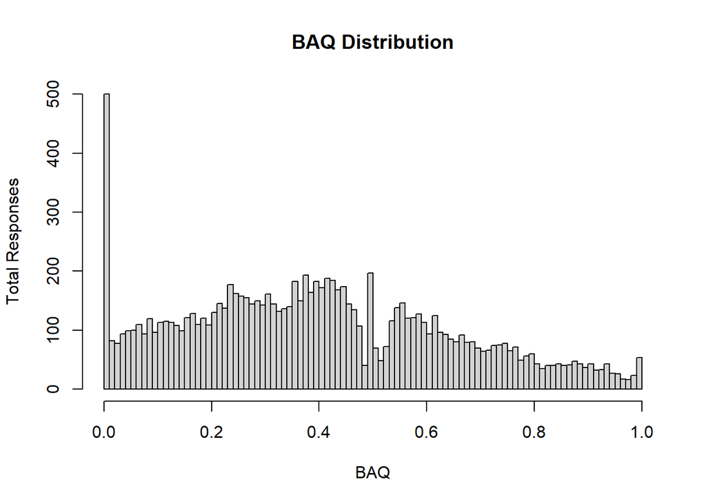

Boxplot of BAQ vs. HAAQI across systems:

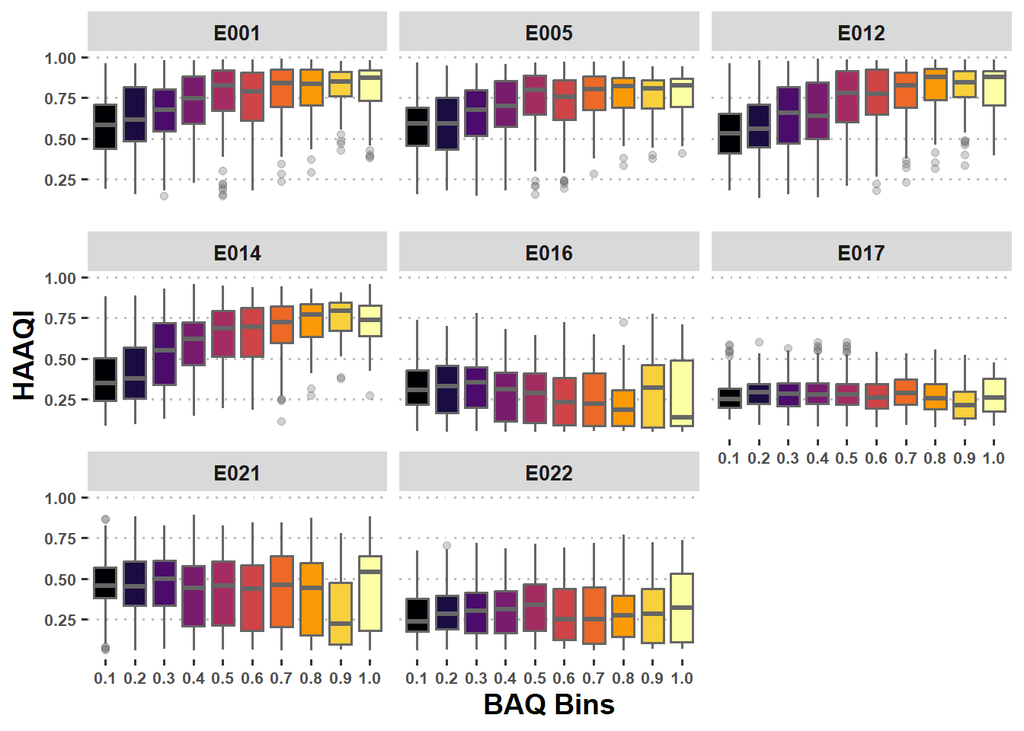

Calculate Spearman rank correlations between BAQ and HAAQI:

| System | Correlation | P_Value |
| --- | --- | --- |
| E017 | -0.0549610173186735 | 0.0471 |
| E012 | 0.431391818323811 | 0 |
| E014 | 0.515005550960324 | 0 |
| E005 | 0.337010733114469 | 0 |
| E021 | -0.0773109408611693 | 0.0052 |
| E022 | 0.0256303824376927 | 0.3549 |
| E016 | -0.136440305524788 | 0 |
| E001 | 0.373289371180452 | 0 |

### Basic Descriptives

Attributes means by system:

| Team | BAQ | Clarity | Harshness | Distortion | Freq_Bal | Liking |
| --- | --- | --- | --- | --- | --- | --- |
| E001 | 0.42 | 0.53 | 0.57 | 0.53 | 0.81 | 0.43 |
| E005 | 0.42 | 0.53 | 0.57 | 0.53 | 0.81 | 0.43 |
| E012 | 0.41 | 0.52 | 0.56 | 0.53 | 0.80 | 0.43 |
| E014 | 0.33 | 0.41 | 0.56 | 0.63 | 0.77 | 0.40 |
| E016 | 0.39 | 0.42 | 0.27 | 0.45 | 0.76 | 0.46 |
| E017 | 0.42 | 0.52 | 0.35 | 0.43 | 0.85 | 0.47 |
| E021 | 0.43 | 0.46 | 0.25 | 0.41 | 0.77 | 0.49 |
| E022 | 0.36 | 0.42 | 0.30 | 0.45 | 0.83 | 0.42 |

Attribute means by HL severity:

| Severity | BAQ | Clarity | Harshness | Distortion | Freq_Bal | Liking |
| --- | --- | --- | --- | --- | --- | --- |
| Mild | 0.45 | 0.53 | 0.39 | 0.45 | 0.85 | 0.46 |
| Moderate | 0.38 | 0.44 | 0.44 | 0.48 | 0.80 | 0.47 |
| Moderately severe | 0.37 | 0.46 | 0.45 | 0.55 | 0.77 | 0.40 |

Intercorrelations between perceptual attributes:

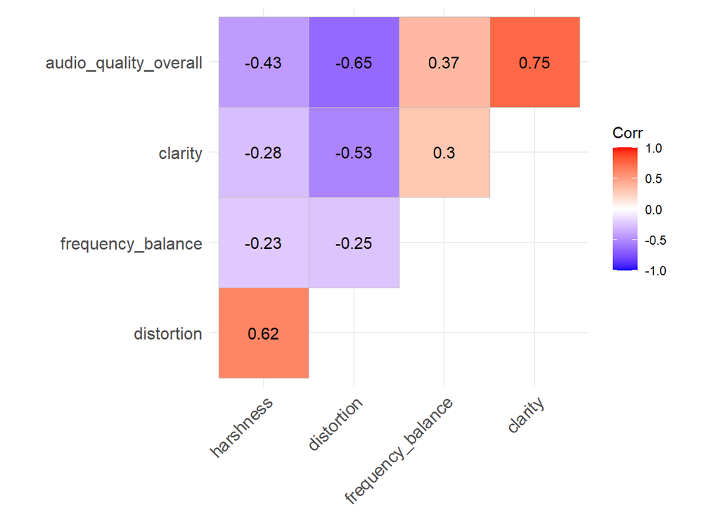

# **BAQ scores across system and HL severity**

### **General linear mixed model approach (allows us to use all of the data)**

Fit GLMM with ordered beta regression method (Kubinec, 2023) - Use “glmmTMB” package. This is to deal with a zero-inflated bounded continuous distribution (i.e., BAQ data):

```r
glmm <- glmmTMB(audio_quality_overall ~ Team * Severity + (1|participant_id) + (1|Song),
                data = df, family = ordbeta(link = 'logit'))
```

Fit standard LMM alternative for model comparisons - use “lmerTest” package

```r
lmm <- lmer(audio_quality_overall ~ Team * Severity + (1|participant_id) + (1|Song),
            data = df, control = lmerControl(optimizer = 'bobyqa'))
```

### **Diagnostics**

Get overall indices of model - using “modelsummary” package

|  | (1) | (2) |
| --- | --- | --- |
| (Intercept) | -0.018 | 0.493 |
|  | 4.512 | 0.493 |
|  | (0.129) | (0.030) |
| TeamE005 | 0.060 | 0.017 |
|  | (0.062) | (0.015) |
| TeamE012 | 0.010 | 0.007 |
|  | (0.061) | (0.015) |
| TeamE014 | -0.211 | -0.053 |
|  | (0.062) | (0.015) |
| TeamE016 | -0.332 | -0.088 |
|  | (0.062) | (0.015) |
| TeamE017 | -0.199 | -0.057 |
|  | (0.062) | (0.015) |
| TeamE021 | -0.095 | -0.035 |
|  | (0.062) | (0.015) |
| TeamE022 | -0.481 | -0.114 |
|  | (0.063) | (0.015) |
| SeverityModerate | -0.283 | -0.073 |
|  | (0.136) | (0.032) |
| SeverityModerately severe | -0.582 | -0.145 |
|  | (0.133) | (0.031) |
| TeamE005 × SeverityModerate | -0.032 | -0.008 |
|  | (0.085) | (0.020) |
| TeamE012 × SeverityModerate | 0.004 | -0.001 |
|  | (0.084) | (0.020) |
| TeamE014 × SeverityModerate | 0.025 | 0.006 |
|  | (0.085) | (0.020) |
| TeamE016 × SeverityModerate | -0.018 | 0.001 |
|  | (0.085) | (0.020) |
| TeamE017 × SeverityModerate | 0.013 | 0.011 |
|  | (0.085) | (0.020) |
| TeamE021 × SeverityModerate | -0.129 | -0.018 |
|  | (0.085) | (0.020) |
| TeamE022 × SeverityModerate | -0.003 | 0.002 |
|  | (0.086) | (0.020) |
| TeamE005 × SeverityModerately severe | -0.076 | -0.025 |
|  | (0.083) | (0.020) |
| TeamE012 × SeverityModerately severe | -0.079 | -0.025 |
|  | (0.084) | (0.020) |
| TeamE014 × SeverityModerately severe | -0.486 | -0.092 |
|  | (0.086) | (0.020) |
| TeamE016 × SeverityModerately severe | 0.602 | 0.155 |
|  | (0.083) | (0.020) |
| TeamE017 × SeverityModerately severe | 0.576 | 0.147 |
|  | (0.083) | (0.020) |
| TeamE021 × SeverityModerately severe | 0.531 | 0.141 |
|  | (0.083) | (0.020) |
| TeamE022 × SeverityModerately severe | 0.610 | 0.144 |
|  | (0.085) | (0.020) |
| SD (Intercept participant_id) | 0.349 | 0.082 |
| SD (Intercept Song) | 0.405 | 0.096 |
| SD (Observations) |  | 0.205 |
| Num.Obs. | 10450 | 10450 |
| R2 Marg. | 0.138 | 0.074 |
| R2 Cond. | 0.605 | 0.329 |
| AIC | -1223.0 | -3014.8 |
| BIC | -1012.6 | -2818.9 |
| ICC | 0.5 | 0.3 |
| RMSE | 0.20 | 0.20 |

Compare performance metrics between models - using “performance” package

```
## # Comparison of Model Performance Indices
##
## Name |           Model | R2 (cond.) | R2 (marg.) |   ICC |  RMSE | Sigma
## ------------------------------------------------------------------------
## lmm  | lmerModLmerTest |      0.329 |      0.074 | 0.275 | 0.204 | 0.205
## glmm |         glmmTMB |      0.605 |      0.138 | 0.542 | 0.204 | 4.512
##
## Name | AIC weights | AICc weights | BIC weights | Performance-Score
## -------------------------------------------------------------------
## lmm  |        1.00 |         1.00 |        1.00 |            62.50%
## glmm |    0.00e+00 |     0.00e+00 |    0.00e+00 |            37.50%
```

Check residuals, outliers, dispersion issues (1st for GLMM, 2nd for alt LMM):

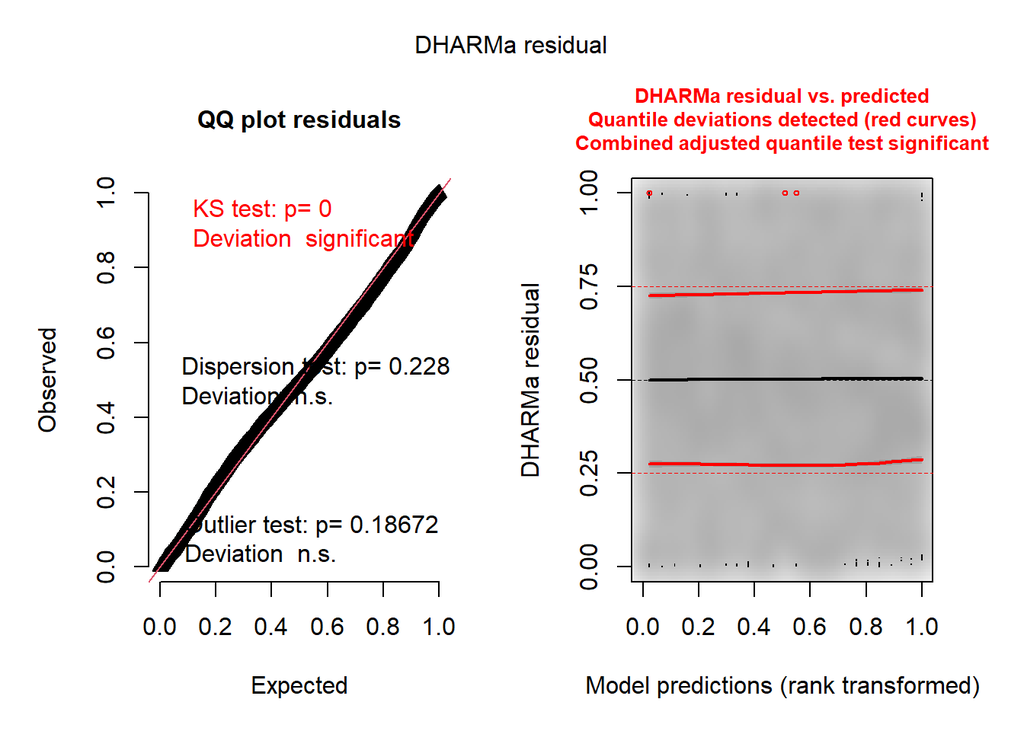

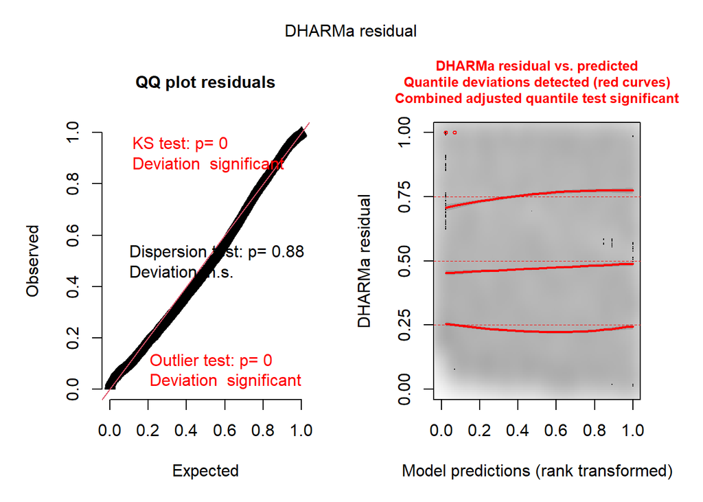

Summarise GLMM:

```
##  Family: ordbeta  ( logit )
## Formula:
## audio_quality_overall ~ Team * Severity + (1 | participant_id) +
##     (1 | Song)
## Data: df
##
##       AIC       BIC    logLik -2*log(L)  df.resid
##   -1223.0   -1012.6     640.5   -1281.0     10421
##
## Random effects:
##
## Conditional model:
##  Groups         Name        Variance Std.Dev.
##  participant_id (Intercept) 0.1217   0.3488
##  Song           (Intercept) 0.1639   0.4048
## Number of obs: 10450, groups:  participant_id, 53; Song, 25
##
## Dispersion parameter for ordbeta family (): 4.51
##
## Conditional model:
##                                     Estimate Std. Error z value Pr(>|z|)
## (Intercept)                        -0.018455   0.128750  -0.143 0.886019
## TeamE005                            0.060410   0.061591   0.981 0.326678
## TeamE012                            0.010332   0.061496   0.168 0.866570
## TeamE014                           -0.211065   0.062220  -3.392 0.000693 ***
## TeamE016                           -0.331668   0.061853  -5.362 8.22e-08 ***
## TeamE017                           -0.199013   0.061737  -3.224 0.001266 **
## TeamE021                           -0.094578   0.061771  -1.531 0.125745
## TeamE022                           -0.481495   0.062755  -7.673 1.69e-14 ***
## SeverityModerate                   -0.283218   0.135738  -2.086 0.036934 *
## SeverityModerately severe          -0.582408   0.132886  -4.383 1.17e-05 ***
## TeamE005:SeverityModerate          -0.031754   0.084514  -0.376 0.707120
## TeamE012:SeverityModerate           0.004050   0.084344   0.048 0.961705
## TeamE014:SeverityModerate           0.025280   0.085374   0.296 0.767146
## TeamE016:SeverityModerate          -0.017871   0.085257  -0.210 0.833969
## TeamE017:SeverityModerate           0.012656   0.085074   0.149 0.881744
## TeamE021:SeverityModerate          -0.129329   0.085269  -1.517 0.129336
## TeamE022:SeverityModerate          -0.002803   0.086173  -0.033 0.974047
## TeamE005:SeverityModerately severe -0.075868   0.083452  -0.909 0.363283
## TeamE012:SeverityModerately severe -0.079269   0.083750  -0.946 0.343894
## TeamE014:SeverityModerately severe -0.485693   0.085835  -5.658 1.53e-08 ***
## TeamE016:SeverityModerately severe  0.601735   0.083377   7.217 5.31e-13 ***
## TeamE017:SeverityModerately severe  0.575525   0.083243   6.914 4.72e-12 ***
## TeamE021:SeverityModerately severe  0.530837   0.083407   6.364 1.96e-10 ***
## TeamE022:SeverityModerately severe  0.609946   0.084657   7.205 5.81e-13 ***
## ---
## Signif. codes:  0 '***' 0.001 '**' 0.01 '*' 0.05 '.' 0.1 ' ' 1
```

### **Post-hoc comparisons**

Using the “emmeans” package, first look at system effects:

```
## NOTE: Results may be misleading due to involvement in interactions
```

```
##  Team response     SE  df asymp.LCL asymp.UCL
##  E001    0.424 0.0238 Inf     0.378     0.471
##  E005    0.430 0.0238 Inf     0.384     0.477
##  E012    0.420 0.0237 Inf     0.375     0.467
##  E014    0.338 0.0218 Inf     0.297     0.382
##  E016    0.391 0.0232 Inf     0.346     0.437
##  E017    0.423 0.0237 Inf     0.377     0.470
##  E021    0.433 0.0239 Inf     0.387     0.481
##  E022    0.358 0.0224 Inf     0.315     0.403
##
## Results are averaged over the levels of: Severity
## Confidence level used: 0.95
## Intervals are back-transformed from the logit scale
```

```
## NOTE: Results may be misleading due to involvement in interactions
```

```
##  contrast    odds.ratio     SE  df null z.ratio p.value
##  E001 / E005      0.976 0.0330 Inf    1  -0.725  0.9963
##  E001 / E012      1.015 0.0344 Inf    1   0.435  0.9999
##  E001 / E014      1.440 0.0499 Inf    1  10.524  <.0001
##  E001 / E016      1.147 0.0390 Inf    1   4.032  0.0014
##  E001 / E017      1.003 0.0340 Inf    1   0.087  1.0000
##  E001 / E021      0.962 0.0327 Inf    1  -1.154  0.9445
##  E001 / E022      1.322 0.0455 Inf    1   8.105  <.0001
##  E005 / E012      1.040 0.0352 Inf    1   1.162  0.9426
##  E005 / E014      1.476 0.0510 Inf    1  11.266  <.0001
##  E005 / E016      1.175 0.0398 Inf    1   4.769  0.0001
##  E005 / E017      1.028 0.0348 Inf    1   0.813  0.9925
##  E005 / E021      0.985 0.0334 Inf    1  -0.434  0.9999
##  E005 / E022      1.355 0.0465 Inf    1   8.844  <.0001
##  E012 / E014      1.419 0.0491 Inf    1  10.116  <.0001
##  E012 / E016      1.130 0.0384 Inf    1   3.604  0.0076
##  E012 / E017      0.988 0.0335 Inf    1  -0.348  1.0000
##  E012 / E021      0.947 0.0322 Inf    1  -1.590  0.7564
##  E012 / E022      1.303 0.0448 Inf    1   7.690  <.0001
##  E014 / E016      0.797 0.0276 Inf    1  -6.566  <.0001
##  E014 / E017      0.697 0.0241 Inf    1 -10.450  <.0001
##  E014 / E021      0.668 0.0232 Inf    1 -11.641  <.0001
##  E014 / E022      0.918 0.0322 Inf    1  -2.436  0.2239
##  E016 / E017      0.875 0.0297 Inf    1  -3.953  0.0020
##  E016 / E021      0.838 0.0285 Inf    1  -5.185  <.0001
##  E016 / E022      1.153 0.0397 Inf    1   4.129  0.0010
##  E017 / E021      0.959 0.0325 Inf    1  -1.244  0.9188
##  E017 / E022      1.318 0.0453 Inf    1   8.039  <.0001
##  E021 / E022      1.375 0.0474 Inf    1   9.241  <.0001
##
## Results are averaged over the levels of: Severity
## P value adjustment: tukey method for comparing a family of 8 estimates
## Tests are performed on the log odds ratio scale
```

```
## NOTE: Results may be misleading due to involvement in interactions
```

```
##  contrast    odds.ratio     SE  df asymp.LCL asymp.UCL
##  E001 / E005      0.976 0.0330 Inf     0.881     1.081
##  E001 / E012      1.015 0.0344 Inf     0.916     1.125
##  E001 / E014      1.440 0.0499 Inf     1.296     1.599
##  E001 / E016      1.147 0.0390 Inf     1.035     1.271
##  E001 / E017      1.003 0.0340 Inf     0.905     1.112
##  E001 / E021      0.962 0.0327 Inf     0.867     1.066
##  E001 / E022      1.322 0.0455 Inf     1.191     1.467
##  E005 / E012      1.040 0.0352 Inf     0.939     1.152
##  E005 / E014      1.476 0.0510 Inf     1.329     1.638
##  E005 / E016      1.175 0.0398 Inf     1.061     1.302
##  E005 / E017      1.028 0.0348 Inf     0.928     1.139
##  E005 / E021      0.985 0.0334 Inf     0.889     1.092
##  E005 / E022      1.355 0.0465 Inf     1.221     1.503
##  E012 / E014      1.419 0.0491 Inf     1.278     1.576
##  E012 / E016      1.130 0.0384 Inf     1.020     1.253
##  E012 / E017      0.988 0.0335 Inf     0.892     1.095
##  E012 / E021      0.947 0.0322 Inf     0.855     1.050
##  E012 / E022      1.303 0.0448 Inf     1.174     1.446
##  E014 / E016      0.797 0.0276 Inf     0.717     0.885
##  E014 / E017      0.697 0.0241 Inf     0.627     0.774
##  E014 / E021      0.668 0.0232 Inf     0.601     0.742
##  E014 / E022      0.918 0.0322 Inf     0.826     1.021
##  E016 / E017      0.875 0.0297 Inf     0.789     0.969
##  E016 / E021      0.838 0.0285 Inf     0.756     0.929
##  E016 / E022      1.153 0.0397 Inf     1.038     1.279
##  E017 / E021      0.959 0.0325 Inf     0.865     1.063
##  E017 / E022      1.318 0.0453 Inf     1.188     1.463
##  E021 / E022      1.375 0.0474 Inf     1.239     1.526
##
## Results are averaged over the levels of: Severity
## Confidence level used: 0.95
## Conf-level adjustment: tukey method for comparing a family of 8 estimates
## Intervals are back-transformed from the log odds ratio scale
```

Next, HL severity:

```
## NOTE: Results may be misleading due to involvement in interactions
```

```
##  Severity          response     SE  df asymp.LCL asymp.UCL
##  Mild                 0.457 0.0303 Inf     0.398     0.516
##  Moderate             0.383 0.0275 Inf     0.331     0.438
##  Moderately severe    0.367 0.0263 Inf     0.317     0.419
##
## Results are averaged over the levels of: Team
## Confidence level used: 0.95
## Intervals are back-transformed from the logit scale
```

```
## NOTE: Results may be misleading due to involvement in interactions
```

```
##  contrast                     odds.ratio    SE  df null z.ratio p.value
##  Mild / Moderate                    1.35 0.167 Inf    1   2.433  0.0397
##  Mild / Moderately severe           1.45 0.175 Inf    1   3.084  0.0058
##  Moderate / Moderately severe       1.07 0.123 Inf    1   0.631  0.8030
##
## Results are averaged over the levels of: Team
## P value adjustment: tukey method for comparing a family of 3 estimates
## Tests are performed on the log odds ratio scale
```

```
## NOTE: Results may be misleading due to involvement in interactions
```

```
##  contrast                     odds.ratio    SE  df asymp.LCL asymp.UCL
##  Mild / Moderate                    1.35 0.167 Inf     1.011      1.80
##  Mild / Moderately severe           1.45 0.175 Inf     1.094      1.93
##  Moderate / Moderately severe       1.07 0.123 Inf     0.822      1.40
##
## Results are averaged over the levels of: Team
## Confidence level used: 0.95
## Conf-level adjustment: tukey method for comparing a family of 3 estimates
## Intervals are back-transformed from the log odds ratio scale
```

Finally, system and HL interactions:

```
## Team = E001:
##  Severity          response     SE  df asymp.LCL asymp.UCL
##  Mild                 0.495 0.0322 Inf     0.433     0.558
##  Moderate             0.425 0.0299 Inf     0.368     0.485
##  Moderately severe    0.354 0.0273 Inf     0.303     0.409
##
## Team = E005:
##  Severity          response     SE  df asymp.LCL asymp.UCL
##  Mild                 0.510 0.0322 Inf     0.448     0.573
##  Moderate             0.432 0.0300 Inf     0.375     0.492
##  Moderately severe    0.351 0.0271 Inf     0.299     0.405
##
## Team = E012:
##  Severity          response     SE  df asymp.LCL asymp.UCL
##  Mild                 0.498 0.0322 Inf     0.435     0.561
##  Moderate             0.429 0.0299 Inf     0.371     0.488
##  Moderately severe    0.339 0.0268 Inf     0.288     0.393
##
## Team = E014:
##  Severity          response     SE  df asymp.LCL asymp.UCL
##  Mild                 0.443 0.0318 Inf     0.382     0.506
##  Moderate             0.380 0.0289 Inf     0.326     0.438
##  Moderately severe    0.215 0.0203 Inf     0.177     0.257
##
## Team = E016:
##  Severity          response     SE  df asymp.LCL asymp.UCL
##  Mild                 0.413 0.0312 Inf     0.354     0.476
##  Moderate             0.343 0.0276 Inf     0.291     0.399
##  Moderately severe    0.418 0.0289 Inf     0.363     0.476
##
## Team = E017:
##  Severity          response     SE  df asymp.LCL asymp.UCL
##  Mild                 0.446 0.0318 Inf     0.385     0.509
##  Moderate             0.380 0.0289 Inf     0.326     0.438
##  Moderately severe    0.444 0.0294 Inf     0.388     0.502
##
## Team = E021:
##  Severity          response     SE  df asymp.LCL asymp.UCL
##  Mild                 0.472 0.0321 Inf     0.410     0.535
##  Moderate             0.372 0.0286 Inf     0.317     0.429
##  Moderately severe    0.459 0.0295 Inf     0.402     0.517
##
## Team = E022:
##  Severity          response     SE  df asymp.LCL asymp.UCL
##  Mild                 0.378 0.0304 Inf     0.320     0.439
##  Moderate             0.313 0.0264 Inf     0.264     0.367
##  Moderately severe    0.384 0.0282 Inf     0.330     0.441
##
## Confidence level used: 0.95
## Intervals are back-transformed from the logit scale
```

```
## Team = E001:
##  contrast                     odds.ratio     SE  df null z.ratio p.value
##  Mild / Moderate                   1.327 0.1800 Inf    1   2.086  0.0926
##  Mild / Moderately severe          1.790 0.2380 Inf    1   4.383  <.0001
##  Moderate / Moderately severe      1.349 0.1700 Inf    1   2.372  0.0466
##
## Team = E005:
##  contrast                     odds.ratio     SE  df null z.ratio p.value
##  Mild / Moderate                   1.370 0.1860 Inf    1   2.324  0.0525
##  Mild / Moderately severe          1.931 0.2570 Inf    1   4.955  <.0001
##  Moderate / Moderately severe      1.410 0.1780 Inf    1   2.724  0.0177
##
## Team = E012:
##  contrast                     odds.ratio     SE  df null z.ratio p.value
##  Mild / Moderate                   1.322 0.1790 Inf    1   2.062  0.0979
##  Mild / Moderately severe          1.938 0.2580 Inf    1   4.973  <.0001
##  Moderate / Moderately severe      1.466 0.1850 Inf    1   3.031  0.0069
##
## Team = E014:
##  contrast                     odds.ratio     SE  df null z.ratio p.value
##  Mild / Moderate                   1.294 0.1760 Inf    1   1.895  0.1400
##  Mild / Moderately severe          2.910 0.3910 Inf    1   7.947  <.0001
##  Moderate / Moderately severe      2.248 0.2870 Inf    1   6.347  <.0001
##
## Team = E016:
##  contrast                     odds.ratio     SE  df null z.ratio p.value
##  Mild / Moderate                   1.351 0.1840 Inf    1   2.215  0.0687
##  Mild / Moderately severe          0.981 0.1300 Inf    1  -0.146  0.9884
##  Moderate / Moderately severe      0.726 0.0915 Inf    1  -2.541  0.0298
##
## Team = E017:
##  contrast                     odds.ratio     SE  df null z.ratio p.value
##  Mild / Moderate                   1.311 0.1780 Inf    1   1.992  0.1141
##  Mild / Moderately severe          1.007 0.1340 Inf    1   0.052  0.9985
##  Moderate / Moderately severe      0.768 0.0968 Inf    1  -2.093  0.0913
##
## Team = E021:
##  contrast                     odds.ratio     SE  df null z.ratio p.value
##  Mild / Moderate                   1.511 0.2050 Inf    1   3.034  0.0068
##  Mild / Moderately severe          1.053 0.1400 Inf    1   0.389  0.9201
##  Moderate / Moderately severe      0.697 0.0878 Inf    1  -2.865  0.0116
##
## Team = E022:
##  contrast                     odds.ratio     SE  df null z.ratio p.value
##  Mild / Moderate                   1.331 0.1820 Inf    1   2.095  0.0908
##  Mild / Moderately severe          0.973 0.1300 Inf    1  -0.206  0.9768
##  Moderate / Moderately severe      0.731 0.0926 Inf    1  -2.474  0.0356
##
## P value adjustment: tukey method for comparing a family of 3 estimates
## Tests are performed on the log odds ratio scale
```

```
## Team = E001:
##  contrast                     odds.ratio     SE  df asymp.LCL asymp.UCL
##  Mild / Moderate                   1.327 0.1800 Inf     0.966     1.825
##  Mild / Moderately severe          1.790 0.2380 Inf     1.311     2.445
##  Moderate / Moderately severe      1.349 0.1700 Inf     1.004     1.813
##
## Team = E005:
##  contrast                     odds.ratio     SE  df asymp.LCL asymp.UCL
##  Mild / Moderate                   1.370 0.1860 Inf     0.997     1.882
##  Mild / Moderately severe          1.931 0.2570 Inf     1.415     2.637
##  Moderate / Moderately severe      1.410 0.1780 Inf     1.049     1.894
##
## Team = E012:
##  contrast                     odds.ratio     SE  df asymp.LCL asymp.UCL
##  Mild / Moderate                   1.322 0.1790 Inf     0.963     1.816
##  Mild / Moderately severe          1.938 0.2580 Inf     1.419     2.647
##  Moderate / Moderately severe      1.466 0.1850 Inf     1.091     1.970
##
## Team = E014:
##  contrast                     odds.ratio     SE  df asymp.LCL asymp.UCL
##  Mild / Moderate                   1.294 0.1760 Inf     0.941     1.781
##  Mild / Moderately severe          2.910 0.3910 Inf     2.124     3.987
##  Moderate / Moderately severe      2.248 0.2870 Inf     1.667     3.032
##
## Team = E016:
##  contrast                     odds.ratio     SE  df asymp.LCL asymp.UCL
##  Mild / Moderate                   1.351 0.1840 Inf     0.983     1.858
##  Mild / Moderately severe          0.981 0.1300 Inf     0.719     1.339
##  Moderate / Moderately severe      0.726 0.0915 Inf     0.540     0.975
##
## Team = E017:
##  contrast                     odds.ratio     SE  df asymp.LCL asymp.UCL
##  Mild / Moderate                   1.311 0.1780 Inf     0.953     1.802
##  Mild / Moderately severe          1.007 0.1340 Inf     0.738     1.374
##  Moderate / Moderately severe      0.768 0.0968 Inf     0.572     1.032
##
## Team = E021:
##  contrast                     odds.ratio     SE  df asymp.LCL asymp.UCL
##  Mild / Moderate                   1.511 0.2050 Inf     1.098     2.078
##  Mild / Moderately severe          1.053 0.1400 Inf     0.772     1.437
##  Moderate / Moderately severe      0.697 0.0878 Inf     0.519     0.936
##
## Team = E022:
##  contrast                     odds.ratio     SE  df asymp.LCL asymp.UCL
##  Mild / Moderate                   1.331 0.1820 Inf     0.967     1.833
##  Mild / Moderately severe          0.973 0.1300 Inf     0.711     1.330
##  Moderate / Moderately severe      0.731 0.0926 Inf     0.543     0.984
##
## Confidence level used: 0.95
## Conf-level adjustment: tukey method for comparing a family of 3 estimates
## Intervals are back-transformed from the log odds ratio scale
```

### **Visualise results**

Visualise BAQ scores by system:

```
## # A tibble: 8 × 2
##   Team  audio_quality_overall
##   <chr>                 <dbl>
## 1 E001                  0.417
## 2 E005                  0.422
## 3 E012                  0.415
## 4 E014                  0.332
## 5 E016                  0.387
## 6 E017                  0.418
## 7 E021                  0.427
## 8 E022                  0.356
```

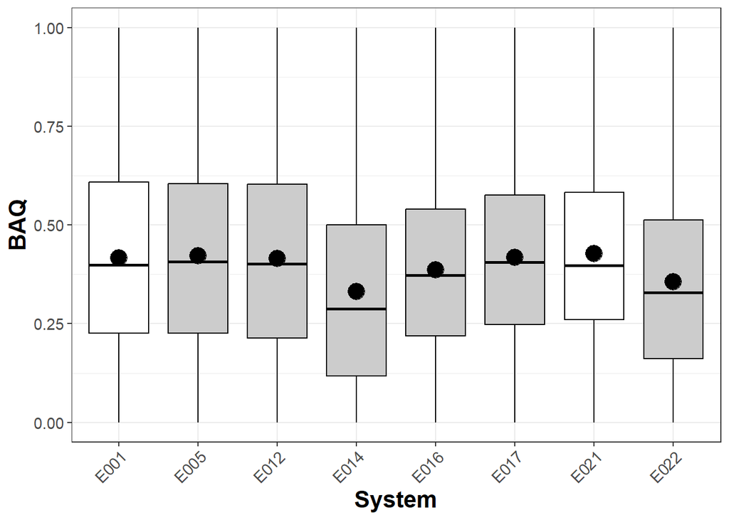

Visualise BAQ scores by HL severity:

```
## # A tibble: 3 × 2
##   Severity          audio_quality_overall
##   <chr>                             <dbl>
## 1 Mild                              0.453
## 2 Moderate                          0.378
## 3 Moderately severe                 0.370
```

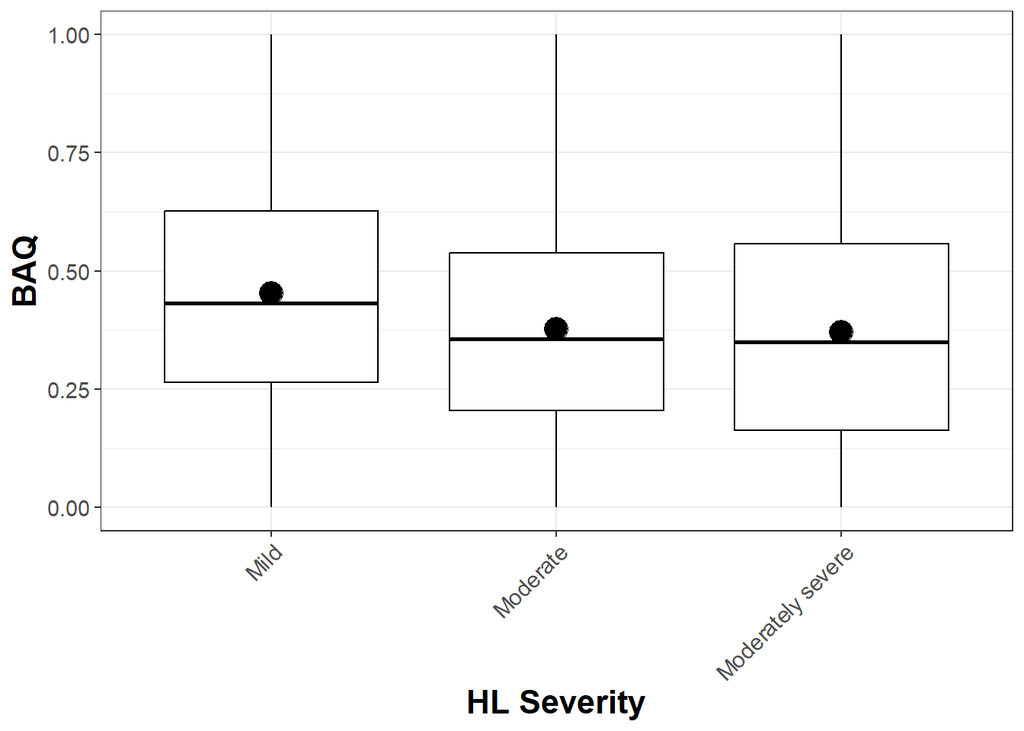

Visualise interactions between system and HL severity:

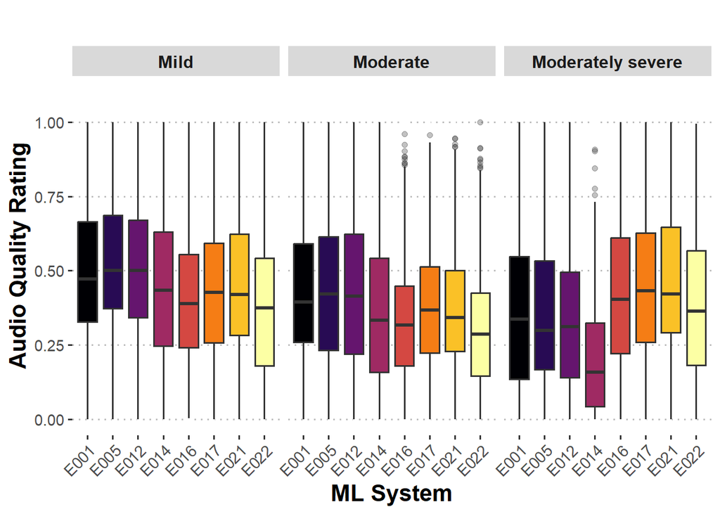

# **Perceptual Attributes and Signal Features**

### **Prepare data for PCA dimensionality reduction

```r
# Extract the audio signal features, and normalise
df2 <- na.omit(df) # Remove rows with missing values to enable PCA
dfNorm <- df2 %>%
  dplyr::select(!Distortion) %>%  # Distortion feature not used; remove
  dplyr::select(19:32)  # Select remaining signal features
dfNorm <- as.data.frame(scale(dfNorm, center = TRUE, scale = TRUE)) # Normalise
```

### **PCA Preparation**

Check assumptions for PCA:

```r
data_matrix = cor(dfNorm, use = 'complete.obs') # Correlation matrix
round(data_matrix, 2) # Remove any variables with a correlation over .90 - "Rolloff" and "Spread" have multiple...
```

```
##              SpecCentroid SpecEntropy SpecFlat SpecFlux SpecKurt SpecRollOff
## SpecCentroid         1.00        0.88     0.88     0.04    -0.28        0.94
## SpecEntropy          0.88        1.00     0.80     0.13    -0.44        0.86
## SpecFlat             0.88        0.80     1.00     0.19    -0.20        0.92
## SpecFlux             0.04        0.13     0.19     1.00    -0.04        0.08
## SpecKurt            -0.28       -0.44    -0.20    -0.04     1.00       -0.30
## SpecRollOff          0.94        0.86     0.92     0.08    -0.30        1.00
## SpecSkew            -0.53       -0.68    -0.38    -0.03     0.91       -0.52
## SpecSlope           -0.02       -0.15    -0.18    -0.97     0.06       -0.07
## SpecSpread           0.88        0.81     0.90     0.11    -0.27        0.98
## CrestFactor         -0.09       -0.16    -0.10    -0.59     0.02       -0.06
## Loud                 0.42        0.48     0.43     0.73    -0.17        0.39
## Rms                  0.23        0.33     0.35     0.90    -0.11        0.24
## Harshness            0.72        0.75     0.51     0.05    -0.32        0.59
## Clipping             0.13        0.27     0.27     0.86    -0.14        0.17
##              SpecSkew SpecSlope SpecSpread CrestFactor  Loud   Rms Harshness
## SpecCentroid    -0.53     -0.02       0.88       -0.09  0.42  0.23      0.72
## SpecEntropy     -0.68     -0.15       0.81       -0.16  0.48  0.33      0.75
## SpecFlat        -0.38     -0.18       0.90       -0.10  0.43  0.35      0.51
## SpecFlux        -0.03     -0.97       0.11       -0.59  0.73  0.90      0.05
## SpecKurt         0.91      0.06      -0.27        0.02 -0.17 -0.11     -0.32
## SpecRollOff     -0.52     -0.07       0.98       -0.06  0.39  0.24      0.59
## SpecSkew         1.00      0.06      -0.47        0.09 -0.29 -0.17     -0.55
## SpecSlope        0.06      1.00      -0.09        0.60 -0.75 -0.93     -0.06
## SpecSpread      -0.47     -0.09       1.00       -0.03  0.36  0.24      0.52
## CrestFactor      0.09      0.60      -0.03        1.00 -0.78 -0.75     -0.12
## Loud            -0.29     -0.75       0.36       -0.78  1.00  0.92      0.40
## Rms             -0.17     -0.93       0.24       -0.75  0.92  1.00      0.23
## Harshness       -0.55     -0.06       0.52       -0.12  0.40  0.23      1.00
## Clipping        -0.17     -0.89       0.17       -0.77  0.80  0.93      0.17
##              Clipping
## SpecCentroid     0.13
## SpecEntropy      0.27
## SpecFlat         0.27
## SpecFlux         0.86
## SpecKurt        -0.14
## SpecRollOff      0.17
## SpecSkew        -0.17
## SpecSlope       -0.89
## SpecSpread       0.17
## CrestFactor     -0.77
## Loud             0.80
## Rms              0.93
## Harshness        0.17
## Clipping         1.00
```

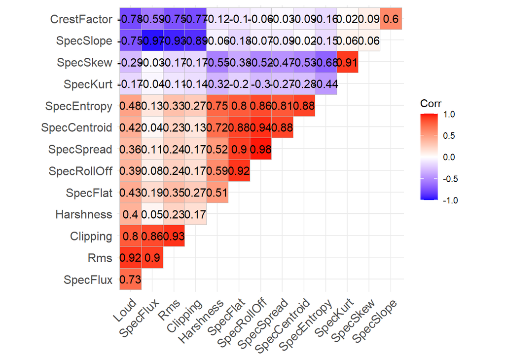

```r
ggcorrplot(data_matrix, type = 'upper', hc.order = TRUE, lab = TRUE)  # Visualise correlations
```

```r
det(data_matrix)  # Falls below .00001
```

```
## [1] 1.682065e-12
```

```r
psych::cortest.bartlett(dfNorm) # Significant, suggesting intercorrelations (good)
```

```
## R was not square, finding R from data
```

```
## $chisq
## [1] 278904.4
##
## $p.value
## [1] 0
##
## $df
## [1] 91
```

```r
psych::KMO(dfNorm)  # Need to evaluate and remove scores lower than 0.60
```

```
## Kaiser-Meyer-Olkin factor adequacy
## Call: psych::KMO(r = dfNorm)
## Overall MSA =  0.75
## MSA for each item =
## SpecCentroid  SpecEntropy     SpecFlat     SpecFlux     SpecKurt  SpecRollOff
##         0.73         0.90         0.85         0.86         0.51         0.67
##     SpecSkew    SpecSlope   SpecSpread  CrestFactor         Loud          Rms
##         0.60         0.77         0.68         0.77         0.75         0.75
##    Harshness     Clipping
##         0.78         0.78
```

Clean data to remove problematic variables, and then check assumptions again:

```r
# Data cleaning after assumptions check
dfNorm <- dfNorm %>%
  dplyr::select(!c(SpecKurt, SpecRollOff, SpecSpread, Rms, SpecSlope)) # Remove variables

# Now re-check assumptions
data_matrix = cor(dfNorm, use = 'complete.obs') # Correlation matrix
round(data_matrix, 2) # No correlations above .90
```

```
##              SpecCentroid SpecEntropy SpecFlat SpecFlux SpecSkew CrestFactor
## SpecCentroid         1.00        0.88     0.88     0.04    -0.53       -0.09
## SpecEntropy          0.88        1.00     0.80     0.13    -0.68       -0.16
## SpecFlat             0.88        0.80     1.00     0.19    -0.38       -0.10
## SpecFlux             0.04        0.13     0.19     1.00    -0.03       -0.59
## SpecSkew            -0.53       -0.68    -0.38    -0.03     1.00        0.09
## CrestFactor         -0.09       -0.16    -0.10    -0.59     0.09        1.00
## Loud                 0.42        0.48     0.43     0.73    -0.29       -0.78
## Harshness            0.72        0.75     0.51     0.05    -0.55       -0.12
## Clipping             0.13        0.27     0.27     0.86    -0.17       -0.77
##               Loud Harshness Clipping
## SpecCentroid  0.42      0.72     0.13
## SpecEntropy   0.48      0.75     0.27
## SpecFlat      0.43      0.51     0.27
## SpecFlux      0.73      0.05     0.86
## SpecSkew     -0.29     -0.55    -0.17
## CrestFactor  -0.78     -0.12    -0.77
## Loud          1.00      0.40     0.80
## Harshness     0.40      1.00     0.17
## Clipping      0.80      0.17     1.00
```

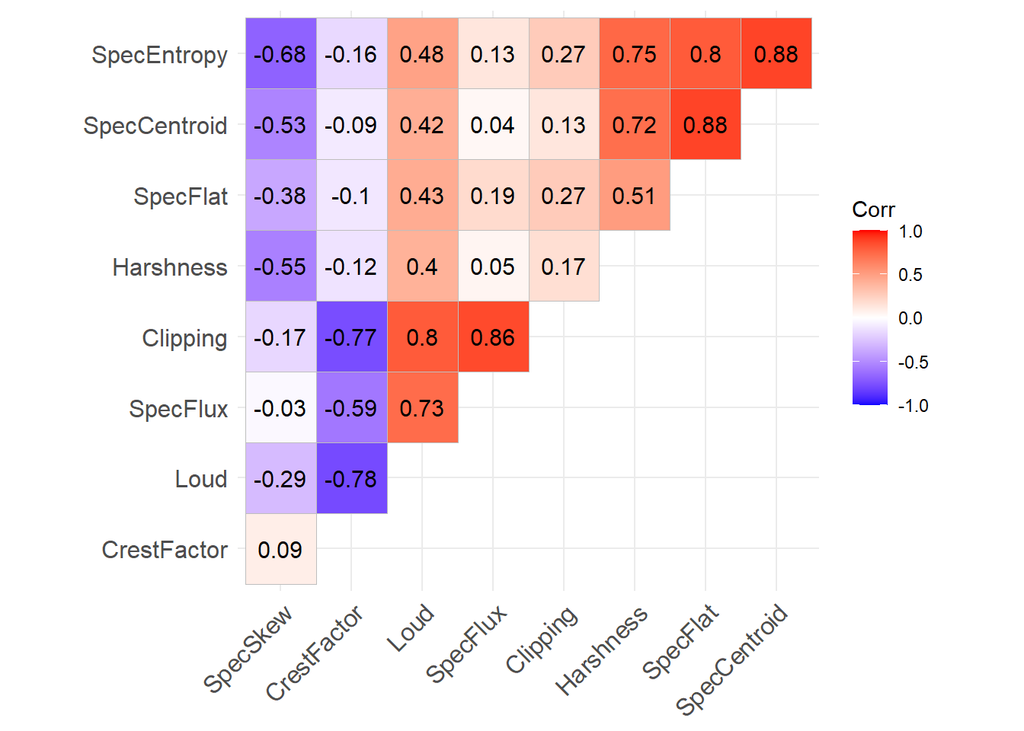

```r
ggcorrplot(data_matrix, type = 'upper', hc.order = TRUE, lab = TRUE)  # Visualise
```

```r
det(data_matrix)  # .00006; good
```

```
## [1] 6.597733e-05
```

```r
psych::cortest.bartlett(dfNorm) # Significant, suggesting intercorrelations (good)
```

```
## R was not square, finding R from data
```

```
## $chisq
## [1] 99045.57
##
## $p.value
## [1] 0
##
## $df
## [1] 36
```

```r
psych::KMO(dfNorm)  # 'crest factor' is < 0.60 - consider removal
```

```
## Kaiser-Meyer-Olkin factor adequacy
## Call: psych::KMO(r = dfNorm)
## Overall MSA =  0.71
## MSA for each item =
## SpecCentroid  SpecEntropy     SpecFlat     SpecFlux     SpecSkew  CrestFactor
##         0.71         0.84         0.66         0.63         0.75         0.58
##         Loud    Harshness     Clipping
##         0.80         0.76         0.65
```

Clean data again to remove “crest factor”, and final assumption check:

```r
# Further data cleaning
dfNorm <- dfNorm %>%
  dplyr::select(!c(CrestFactor))  # Remove variable

# Re-check assumptions
data_matrix = cor(dfNorm, use = 'complete.obs') # Correlation matrix
det(data_matrix)  # .0003
```

```
## [1] 0.0003279401
```

```r
psych::cortest.bartlett(dfNorm) # Significant, suggesting intercorrelations (good)
```

```
## R was not square, finding R from data
```

```
## $chisq
## [1] 82549.36
##
## $p.value
## [1] 0
##
## $df
## [1] 28
```

```r
psych::KMO(dfNorm)  # All items > 0.60 MSA
```

```
## Kaiser-Meyer-Olkin factor adequacy
## Call: psych::KMO(r = dfNorm)
## Overall MSA =  0.76
## MSA for each item =
## SpecCentroid  SpecEntropy     SpecFlat     SpecFlux     SpecSkew         Loud
##         0.71         0.83         0.69         0.75         0.78         0.81
##    Harshness     Clipping
##         0.82         0.68
```

### **Run PCA using “FactoMineR” package**

PCA:

```r
pcdat <- PCA(dfNorm)
```

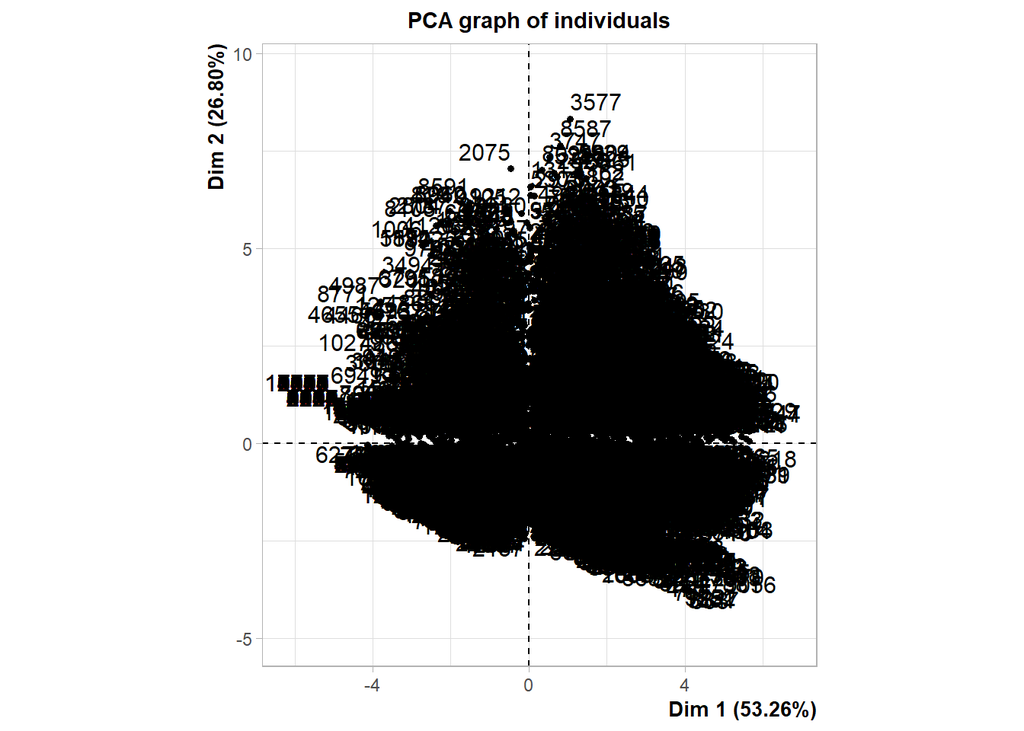

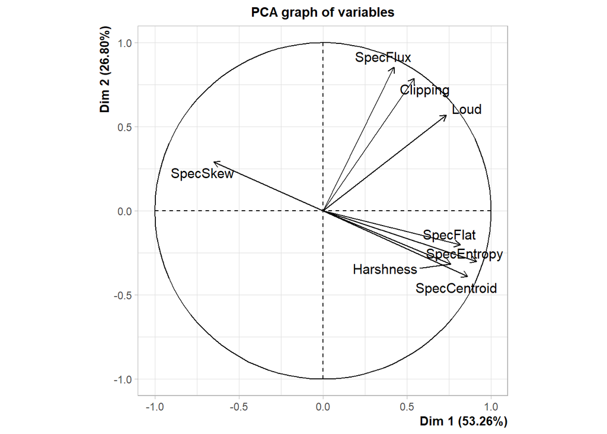

Get eigenvalues:

```
##        eigenvalue percentage of variance cumulative percentage of variance
## comp 1 4.26056517             53.2570646                          53.25706
## comp 2 2.14388111             26.7985139                          80.05558
## comp 3 0.70533913              8.8167391                          88.87232
## comp 4 0.42521593              5.3151992                          94.18752
## comp 5 0.19138325              2.3922906                          96.57981
## comp 6 0.12952126              1.6190158                          98.19882
## comp 7 0.09106268              1.1382835                          99.33711
## comp 8 0.05303147              0.6628934                         100.00000
```

Scree plot (suggesting 2 components):

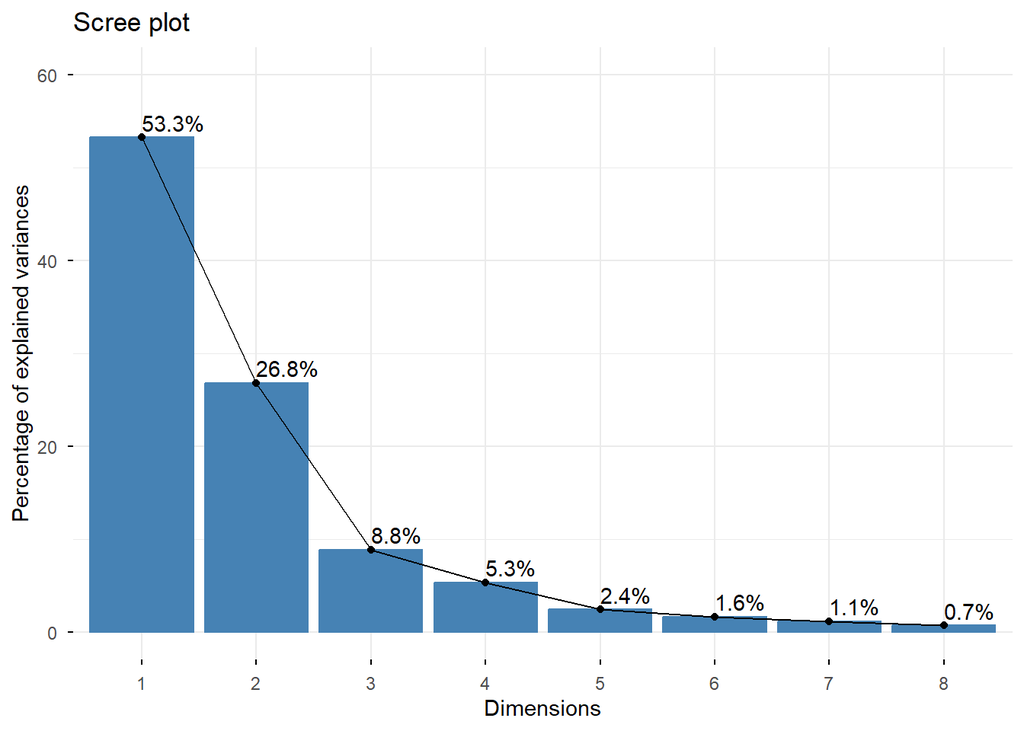

Parallel analysis (suggesting 2 components):

```
##
## Using eigendecomposition of correlation matrix.
## Computing: 10%  20%  30%  40%  50%  60%  70%  80%  90%  100%
##
##
## Results of Horn's Parallel Analysis for component retention
## 240 iterations, using the mean estimate
##
## --------------------------------------------------
## Component   Adjusted    Unadjusted    Estimated
##             Eigenvalue  Eigenvalue    Bias
## --------------------------------------------------
## 1           4.219635    4.260565      0.040929
## 2           2.117684    2.143881      0.026196
## --------------------------------------------------
##
## Adjusted eigenvalues > 1 indicate dimensions to retain.
## (2 components retained)
```

Check communalities (easiest to replicate using “principal” function)

```
## SpecCentroid  SpecEntropy     SpecFlat     SpecFlux     SpecSkew         Loud
##    0.8953191    0.9245740    0.7093899    0.9084647    0.5079732    0.8616619
##    Harshness     Clipping
##    0.6805289    0.9165346
```

### **Visualise PCA**

Visualise variance and then contribution:

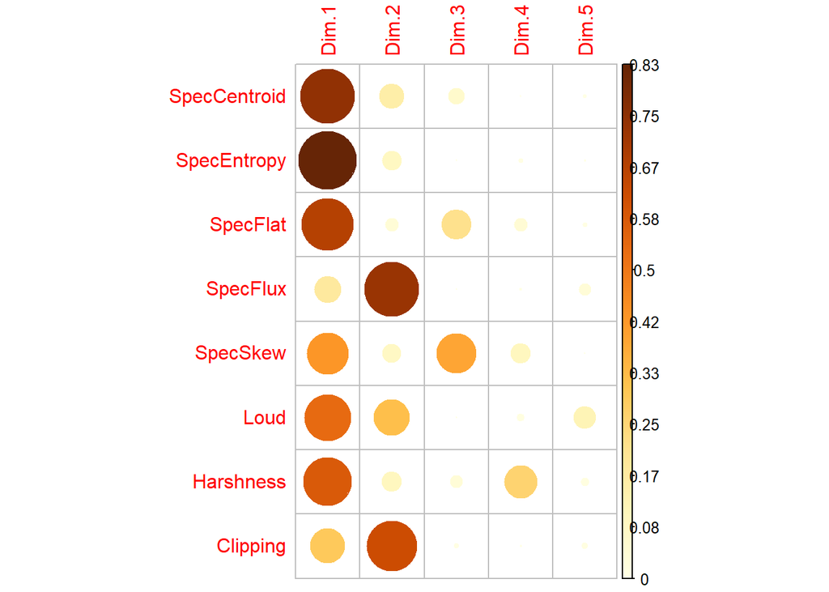

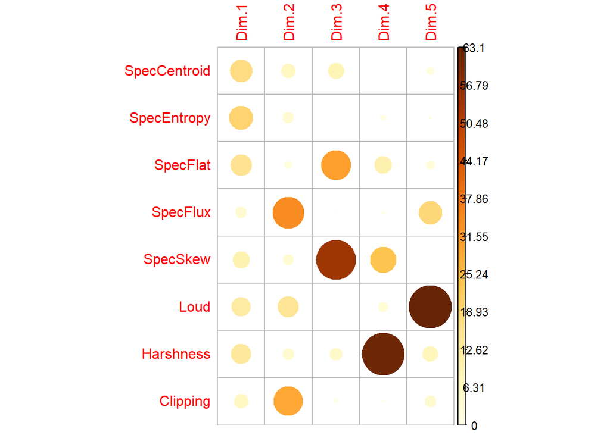

Plot dimensions and cos2 values for signal features:

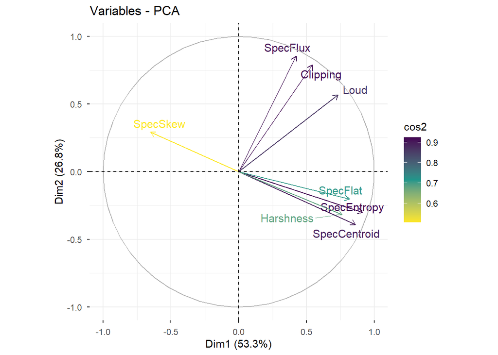

Visualise contribution of signal features to each principal component:

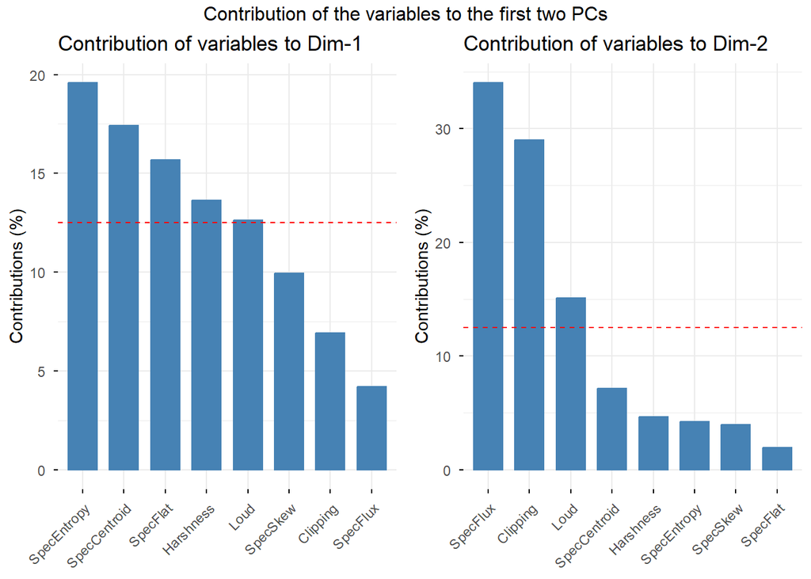

### **Explore perceptual attributes and BAQ in the PCA, as supplementary variables**

plot:

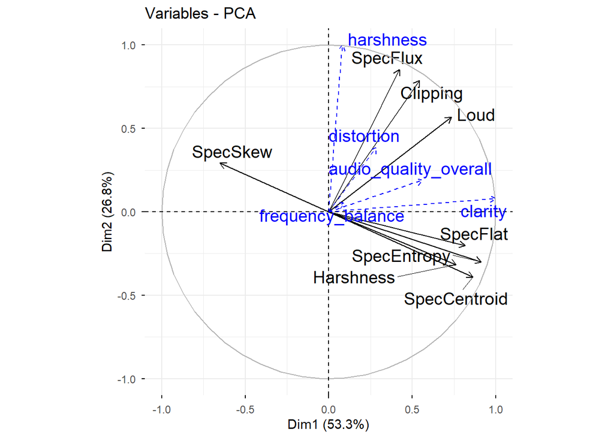

### **Run final PCA with varimax rotation for improved interpretation**

```r
pcmax <- psych::principal(dfNorm, nfactors = 2, rotate = 'varimax')
pcmax$fit
```

```
## [1] 0.9683792
```

```r
pcmax$loadings
```

```
##
## Loadings:
##              RC1    RC2
## SpecCentroid  0.944
## SpecEntropy   0.947  0.166
## SpecFlat      0.816  0.207
## SpecFlux             0.953
## SpecSkew     -0.711
## Loud          0.378  0.848
## Harshness     0.821
## Clipping      0.107  0.951
##
##                  RC1   RC2
## SS loadings    3.790 2.615
## Proportion Var 0.474 0.327
## Cumulative Var 0.474 0.801
```

We then add component scores to our main dataset, for visualising and modelling.

### **Characterise ML systems based on PCA components**

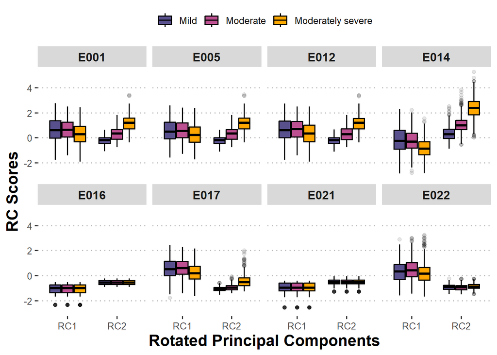

### **Zoom in on PC2 scores for the systems; connections to BAQ?**

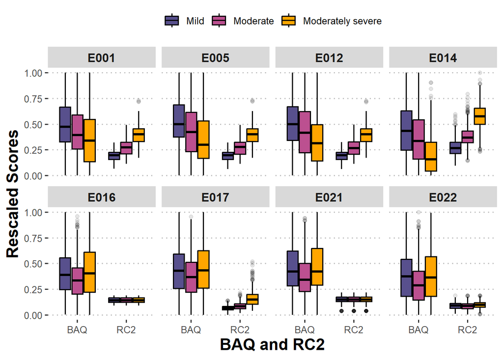

### **Run GLMM with PCs as predictors of BAQ**

```r
# First model = include just the first PC
model01 <- glmmTMB(audio_quality_overall ~ RC1 + (1|participant_id) + (1|Song), data = df2, family = ordbeta(link = 'logit'))

# Second model = include both PCs
model02 <- glmmTMB(audio_quality_overall ~ RC1 + RC2 + (1|participant_id) + (1|Song), data = df2, family = ordbeta(link = 'logit'))

# Alternative model = LMM approach with both PCs
lmm <- lmer(audio_quality_overall ~ RC1 + RC2 + (1|participant_id) + (1|Song), data = df2, control = lmerControl(optimizer = 'bobyqa'))
```

Diagnostics and model comparisons:

```
## # Comparison of Model Performance Indices
##
## Name    |           Model | R2 (cond.) | R2 (marg.) |   ICC |  RMSE | Sigma
## ---------------------------------------------------------------------------
## lmm     | lmerModLmerTest |      0.300 |      0.040 | 0.271 | 0.207 | 0.208
## model02 |         glmmTMB |      0.573 |      0.077 | 0.537 | 0.208 | 4.335
## model01 |         glmmTMB |      0.559 |      0.008 | 0.556 | 0.212 | 4.206
##
## Name    | AIC weights | AICc weights | BIC weights | Performance-Score
## ----------------------------------------------------------------------
## lmm     |        1.00 |         1.00 |        1.00 |            68.28%
## model02 |    0.00e+00 |     0.00e+00 |    0.00e+00 |            45.99%
## model01 |    0.00e+00 |     0.00e+00 |    0.00e+00 |            24.77%
```

|  | (1) | (2) | (3) |
| --- | --- | --- | --- |
| (Intercept) | -0.405 | -0.408 | 0.395 |
|  | -0.405 | 4.335 | 0.395 |
|  | 4.206 | -0.408 | 0.395 |
|  | 4.206 | 4.335 | 0.395 |
|  | (0.098) | (0.093) | (0.022) |
| RC1 | 0.068 | 0.065 | 0.017 |
|  | (0.012) | (0.012) | (0.003) |
| RC2 |  | -0.201 | -0.046 |
|  |  | (0.010) | (0.002) |
| SD (Intercept participant_id) | 0.380 | 0.375 | 0.087 |
| SD (Intercept Song) | 0.415 | 0.383 | 0.092 |
| SD (Observations) |  |  | 0.208 |
| Num.Obs. | 10294 | 10294 | 10294 |
| R2 Marg. | 0.008 | 0.077 | 0.040 |
| R2 Cond. | 0.559 | 0.573 | 0.300 |
| AIC | -521.8 | -908.4 | -2798.6 |
| BIC | -471.1 | -850.5 | -2755.1 |
| ICC | 0.6 | 0.5 | 0.3 |
| RMSE | 0.21 | 0.21 | 0.21 |

Summarise 2nd GLMM model:

```
##  Family: ordbeta  ( logit )
## Formula:
## audio_quality_overall ~ RC1 + RC2 + (1 | participant_id) + (1 |      Song)
## Data: df2
##
##       AIC       BIC    logLik -2*log(L)  df.resid
##    -908.4    -850.5     462.2    -924.4     10286
##
## Random effects:
##
## Conditional model:
##  Groups         Name        Variance Std.Dev.
##  participant_id (Intercept) 0.1408   0.3753
##  Song           (Intercept) 0.1465   0.3828
## Number of obs: 10294, groups:  participant_id, 53; Song, 25
##
## Dispersion parameter for ordbeta family (): 4.33
##
## Conditional model:
##             Estimate Std. Error z value Pr(>|z|)
## (Intercept) -0.40764    0.09276  -4.395 1.11e-05 ***
## RC1          0.06467    0.01178   5.491 4.00e-08 ***
## RC2         -0.20103    0.01020 -19.717  < 2e-16 ***
## ---
## Signif. codes:  0 '***' 0.001 '**' 0.01 '*' 0.05 '.' 0.1 ' ' 1
```